# 状態空間モデル

# 1 状態方程式・観測方程式

線形ガウス状態空間モデルは下記のように定式化される。  
上が状態方程式、下が観測方程式。

$$\begin{aligned}
x_{t}&=T_{t}x_{t-1}+R_{t}\xi _{t}, &~~~~~~\xi _{t}\sim N\left( 0,Q_{t}\right)\\
y_{t}&=Z_{t}x_{t}+\varepsilon_{t}, &~~~~~~\varepsilon _{t}\sim N\left( 0,H_{t}\right)
\end{aligned}\tag{1}$$

$x_{t}$は$t$時点の状態を表す。状態は、$k$次元のベクトルを取る。つまり、状態を様々な要素の和として表現することができる。  
$y_{t}$は$t$時点の観測値。$T_{t}, R_{t}, Z_{t}$はモデルの表現形式を決める行列となる。

日本語だと以下の表現になる。

$$\begin{aligned}
状態 &= 前時点の状態を用いた予測値 + 過程誤差\\
観測 &= 状態 + 観測誤差
\end{aligned}\tag{2}$$

# 2 データの表現とパラメタ推定

データの表現とパラメタ推定は分けて理解すべき。

## 2.1 データの表現

データの表現は、状態方程式と観測方程式で表される。

## 2.2 パラメータ推定

～フィルタ系と、MCMCを用いるグループの大きく2つに分かれる。  
フィルタリングの代表としては、カルマンフィルタが有名。  
MCMCの代表として、HMC法など。  
最も有名な方法は、カルマンフィルタ+最尤法。

## 2.3 状態推定：予測とフィルタリング

フィルタリングは、手に入った**観測値を用いて予測された状態の値を補正**することを指す。  
状態方程式における状態の更新式を用いて予測を行う。

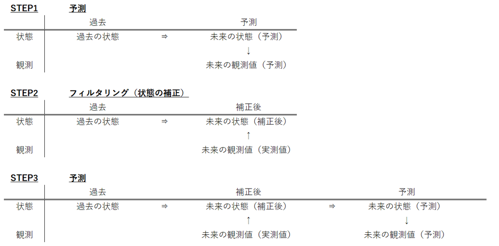

最新の観測地を用いて即座に誤りを補正し、次の予測を行うことができる。  
カルマンフィルタを用いると、これらの計算を効率よく行うことができる。

## 2.4 状態推定：平滑化

平滑化はすべてのデータが整った後に、状態の補正を行う計算を指す。  
未来の観測地を使って、過去の状態を補正しても予測の精度は上がらないが、補正に使われる情報が増えるため、ノイズの影響を軽減できる。

## 2.5 パラメタ推定：最尤法

観測データを用いて状態を補正するためにはいくつかの情報が必要。  
代表的な情報として、過程誤差の分散と、観測誤差の分散。

- 過程誤差が大きい
  - Step1の予測の当たりが悪い事を意味する。予測された未来の状態の精度が悪いので、「観測値を用いた状態の補正」が必要な状態。
- 観測誤差が大きい
  - 観測地をあまり信用できないことを意味する。信用度が低いということは「観測値を用いた状態の補正」はあまり行わない方がいい状態。

つまり、**何方の誤差の大きさの比率を勘案しつつ、フィルタリング（状態の補正）を行う**という事。

このために最尤法を用いたパラメタ推定が行われる。

1. まずは、根拠なしにとりあえずパラメタを設定し、カルマンフィルタを実行する。
2. すると、テキトーに状態の補正が行われてしまう事になる。これを逐次評価して、パラメタの微修正を繰り返すことで最適なパラメタを探す。  
   この時の評価指標を「尤度」と呼び、尤度を最大にするパラメタ推定の方法を最尤法という。
3. たとえば、過程誤差も観測誤差もともに小さな値を設定していたとする。  
   観測データが手に入れば（観測誤差が小さいので）状態は補正されるはず。  
   さらに、過程誤差が小さいので未来の状態も精度よく予測されているはず。  
   正しく補正された上に、精度よく予測された予測結果が、実データと全く異なる値、つまり予測誤差が大きければそれはパラメタ設定が間違っていることとなる。

# 3 線形ガウス状態空間モデルを推定する流れ

0. データの変換（対数変換など）。差分は取る必要がない（定常過程を前提としていないため）。
1. 状態方程式、観測方程式を用いてモデルの構造を表現する。
2. 仮で決めたパラメタを使ってフィルタリングする。
3. カルマンフィルタの結果を援用し、最尤法を用いてパラメタ推定する。
4. 推定されたパラメタを用いて、再度フィルタリングを行う。
5. （必要により）推定されたパラメタを用いて平滑化を行う。

# 4 線形回帰モデルと状態方程式・観測方程式

簡単な、説明変数のない切片だけの線形回帰モデルを

$$\begin{aligned}
y_{t}&=\alpha + v_{t}, &~~~~~~v _{t}\sim N\left( 0,\sigma_{v}^2\right)\\
\end{aligned}\tag{3}$$

仮に、状態方程式・観測方程式で表すと以下になる。

$$\begin{aligned}
x_{t}&=\alpha\\
y_{t}&=x_{t} + v_{t}, &~~~~~~v _{t}\sim N\left( 0,\sigma_{v}^2\right)\\
\end{aligned}\tag{4}$$

誤差項を入れ替えて下にしても同じ

$$\begin{aligned}
x_{t}&=\alpha + w_{t}, &~~~~~~w _{t}\sim N\left( 0,\sigma_{w}^2\right)\\
y_{t}&=x_{t} \\
\end{aligned}\tag{5}$$

(4)式で解釈すると、状態の値が時点によらず一定で、一定の分散の観測誤差だけがあると仮定した状態空間モデルとみなせる。

# 5 自己回帰モデルと状態方程式・観測方程式

# 6 簡単な実装例（カルマンフィルタのコード）

ナイル川の流量データを分析対象とする。  
1年に一回観測され、1871年~1970年まで100年間取得されたデータ。 Rを用いてカルマンフィルタを実装する。  
まず、予測とフィルタリングを行う関数を作成する。

```r
kfLocalLevel <- function(y, mu_pre, P_pre, sigma_w, sigma_v){
  # Step1 予測

  # 状態の予測値 <- 前期の状態
  mu_forecast <- mu_pre

  # 状態の予測誤差の分散(mu_forecastの分散)　<- 前期の状態の予測誤差の分散(mu_preの分散) + 過程誤差の分散
  P_forecast <- P_pre + sigma_w

  # 観測値の予測値 <- 状態の予測値
  y_forecast <- mu_forecast

  # 観測値の予測誤差の分散(y_residの分散) <- 状態の予測誤差の分散(mu_forecastの分散) + 観測誤差の分散
  F_ <- P_forecast + sigma_v


  # Step2 フィルタリング（状態の補正）

  # カルマンゲイン <- 状態の予測誤差の分散(mu_forecastの分散) / (状態の予測誤差の分散(mu_forecastの分散) + 観測誤差の分散)
  K <- P_forecast / (P_forecast + sigma_v)

  # 観測値の予測残差 <- 観測値 - 観測値の予測値
  y_resid <- y - y_forecast

  # 補正後の状態（フィルタ化推定量） <- 状態の予測値 + カルマンゲイン * 観測値の予測残差
  mu_filter <- mu_forecast + K * y_resid

  # フィルタ化推定量の分散（mu_filterの分散） <- (1-カルマンゲイン) * 状態の予測誤差の分散（mu_forecast）
  P_filter <- (1 - K) * P_forecast


  # 結果の格納

  result <- data.frame(mu_filter = mu_filter,
                       P_filter = P_filter,
                       y_resid = y_resid,
                       F_ = F_,
                       K = K
                       )

  return(result)

}
```

上記で作ったカルマンフィルタ関数を、時点をずらしながら何度も実行することで、フィルタ化推定量を求めることができる。  
まずは、フィルタ化推定量を格納する入れ物を用意。  
初期の状態は0に、状態の予測誤差の分散の初期値は10^7と置いた。

```r
# サンプルサイズ
N <- length(Nile)

# 状態の推定値
mu_filter <- numeric(N)

# 状態の初期値は0とする
mu_zero <- 0
mu_filter <- c(mu_zero, mu_filter)

# 状態の予測誤差の分散
P_filter <- numeric(N)


# 状態の予測誤差の分散初期値
P_zero <- 10000000

P_filter <- c(P_zero, P_filter)


# 観測値の予測残差
y_resid <- numeric(N)

# 観測値の予測誤差の分散
F_ <- numeric(N)

# カルマンゲイン
K <- numeric(N)
```

時点0の初期値があるので、配列の長さが異なっている。

mu_filter , P_filter -> n + 1  
yなど -> n

最後に過程誤差・観測誤差の分散を指定する。  
このパラメタは後に最尤法を用いて最適な値に変更する。

```r
# 過程誤差の分散
sigma_w <- 1000

# 観測誤差の分散
sigma_v <- 10000
```

以降、for loopを回して、kfLocalLevel関数を時点をずらしながら連続実行する。

```r
for (i in 1:N){

  kekka <- kfLocalLevel(y = Nile[i],
                        mu_pre = mu_filter[i],
                        P_pre = P_filter[i],
                        sigma_w = sigma_w,
                        sigma_v = sigma_v )

  mu_filter[i + 1] <- kekka$mu_filter
  P_filter[i + 1] <- kekka$P_filter
  y_resid[i] <- kekka$y_resid
  F_[i] <- kekka$F_
  K[i] <- kekka$K

}
```

# 7 KFASの使い方

KFASによるローカルレベルモデル推定

```r
library(KFAS)
library(tidyverse)

# 対象データはナイル川の流量データ
nile_train <- window(Nile, end = 1950)

# 途中に欠損があると仮定
nile_train[41:60] <- NA

# Step1 モデルの構造を決める
# H : 観測誤差の分散
# degree : トレンドモデルを構築（次数を1にすることでローカルレベルモデルにすること示している）
# Q : 過程誤差の分散
# H, QはNAにすることで、不明な値であるとみなしてパラメタ推定してくれる
build_kfas <- SSModel(H = NA,
                      nile_train ~ SSMtrend(degree = 1, Q = NA))

# Step2 パラメタ推定
fit_kfas <- fitSSM(build_kfas, inits = c(1, 1))


# Step3, 4 フィルタリング・スムージング
result_kfas <- KFS(fit_kfas$model,
                   filtering = c("state", "mean"),
                   smoothing = c("state", "mean"))
```

## 7.1 STEP1 モデルの構造を決める

KFASではローカルレベルモデル以外にも、様々なモデルを表現することができる。

- SSMtrend
  - degree = 1 ならローカルレベルモデル
  - degree = 2 ならローカル線形トレンドモデルを組む

```r
# degree = 2の場合のサンプル
# SSMtrend(degree = 2, c(list(NA), list(NA)))
```

- SSMseasonal  
  季節変動を表すことができる
  - period = 12 にすることで、月単位データのような12か月周期になる。
  - sea.type = “dummy” ダミー変数を用いる
  - sea.type = “trigonometric” 三角関数を用いる

```r
# SSMseasonal(period = 12, sea.type = "dummy", Q = NA)
```

- SSMregression  
  外生変数を組み込む。時変係数モデルにも対応。

```r
# SSMregression( ~ 外生変数1 + 外生変数2 + ... , Q = NA)
```

- SSMarima ARIMAモデルと同等モデルを推定
- 複数の要素が入ったモデル

```r
# build_sample <- SSModel(H = NA,
#                         対象データ ~
#                           SSMtrend(degree = 1, Q = NA) # ローカルレベルモデル
#                           SSMregression( ~ 外生変数, Q = NA) # 外生変数
#                           )
```

## 7.2 STEP2 パラメタ推定

fitSSM関数を用いることで、最尤法によるパラメタ推定ができる。  
引数のinits = c(1, 1)は、適当に決めたパラメタ（過程・観測誤差の分散）に当たる。  
これらのパラメタは、最尤法により修正される。

状態の初期値については、散漫初期化という解決策があるが、  
パラメタの初期値は決め打ちするしかない。

ローカルレベルモデルのような単純なモデルでは大きな影響は出ないが、  
複雑なモデルになると、初期値への依存性が出ることがある。  
その場合、初期値をいくつかのパターンで試して最も尤度が高くなった結果を採用するのが良い。

KFASの場合、推定結果は大きく$optim.outと$modelに分かれている。

- $optim.out : 推定されたパラメタ
- $model : 最適なパラメタを用いて組みなおされたモデル

組みなおされたモデル(fit_kfas$model)の持つパラメタを確認する。

```r
# 観測誤差の分散
fit_kfas$model$H
```

```
## , , 1
##
##          [,1]
## [1,] 12782.35
```

```r
# 過程誤差の分散
fit_kfas$model$Q
```

```
## , , 1
##
##          [,1]
## [1,] 2489.915
```

## 7.3 STEP3, 4 フィルタリング・スムージング

KFS関数を用いることでフィルタリングも平滑化も同時に実行できる。  
フィルタリングだけでいい、という場合はsmoothing = “none”のように明示的に使わないと指定する。

```r
# 結果の保存

# フィルタ化推定量
mu_filter_kfas <- result_kfas$a[-1]

# 平滑化状態
mu_smooth_kfas <- result_kfas$alphahat
```

KFS関数の結果では、

- $a : 状態の1期先予測値。当期の観測値を用いた補正（フィルタリング）が行われる前の値であることに注意。  
  ただし、前期の観測値を用いたフィルタリングは行われている。そのため、$aは前期のフィルタ化推定量であるとみなせる。  
  1時点ずれているので、最初の値（観測値がまだ得られていない0時点目のフィルタ化推定量）を[-1]として切り捨てている。  
  （切り捨てられた部分は、散漫初期化されているので意味がない値）
- $alphahat : 平滑化状態

## 7.4 図示

フィルタ化推定量を図示する。

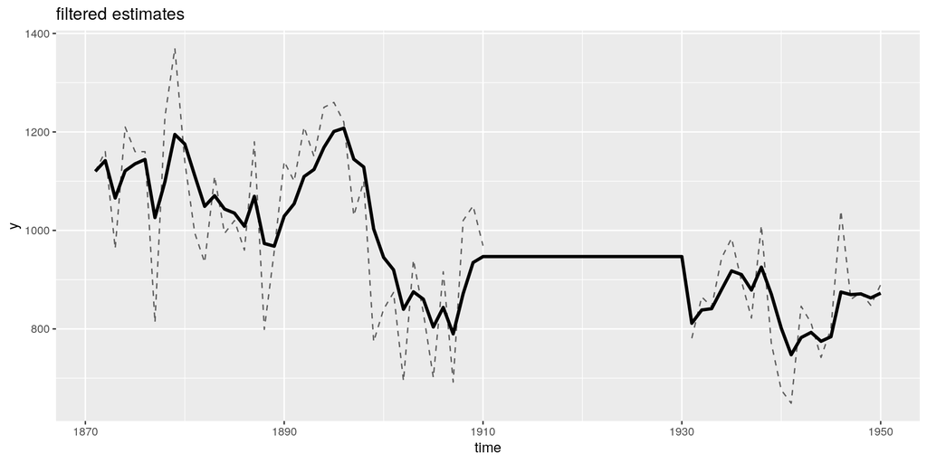

```r
df_filter <- data.frame(y = as.numeric(nile_train[1:80]),
                        time = 1871:1950,
                        mu_filter = mu_filter_kfas)

ggplot(df_filter,
       aes(x = time, y = y)) +
  labs(title = "filtered estimates") +
  geom_line(alpha = 0.6, linetype = "dashed") +
  geom_line(aes(y = mu_filter), size = 1.2)
```

欠損期間で状態がずっと同じ値になっている。  
これがローカルレベルモデル補完の特徴。

## 7.5 KFASによる状態の推定と信頼・予測区間

平滑化状態と、その信頼区間・予測区間を求める。

- 信頼区間：状態が収まるであろう区間
- 予測区間：観測値が収まるであろう区間

予測区間には、観測誤差の大きさも加味されている。

```r
# predict関数を使い信頼区間を求める。
# intercval = confidenceを指定すると、信頼区間となる。
# level = 0.95を指定すると95％信頼区間となる。

smooth_conf <- predict(fit_kfas$model,
                       interval = "confidence",
                       level = 0.95)

head(smooth_conf)
```

```
##           fit       lwr      upr
## [1,] 1113.876  981.9267 1245.826
## [2,] 1112.683  996.8118 1228.555
## [3,] 1102.274  993.8005 1210.747
## [4,] 1118.993 1013.7557 1224.231
## [5,] 1117.986 1014.1255 1221.846
## [6,] 1108.794 1005.5129 1212.075
```

予測区間を求める。  
interval = “prediction” とするだけで予測区間変わる。

```r
smooth_pred <- predict(fit_kfas$model,
                       interval = "prediction",
                       level = 0.95)

head(smooth_pred)
```

```
##           fit      lwr      upr
## [1,] 1113.876 855.9740 1371.779
## [2,] 1112.683 862.6252 1362.742
## [3,] 1102.274 855.5566 1348.991
## [4,] 1118.993 873.6816 1364.305
## [5,] 1117.986 873.2617 1362.710
## [6,] 1108.794 864.3152 1353.273
```

fitの値は平滑化状態の値がそのまま入っている。

## 7.6 KFASによる予測

predict関数内で、n.ahead = 20とすることで、20地点先まで予測ができる。

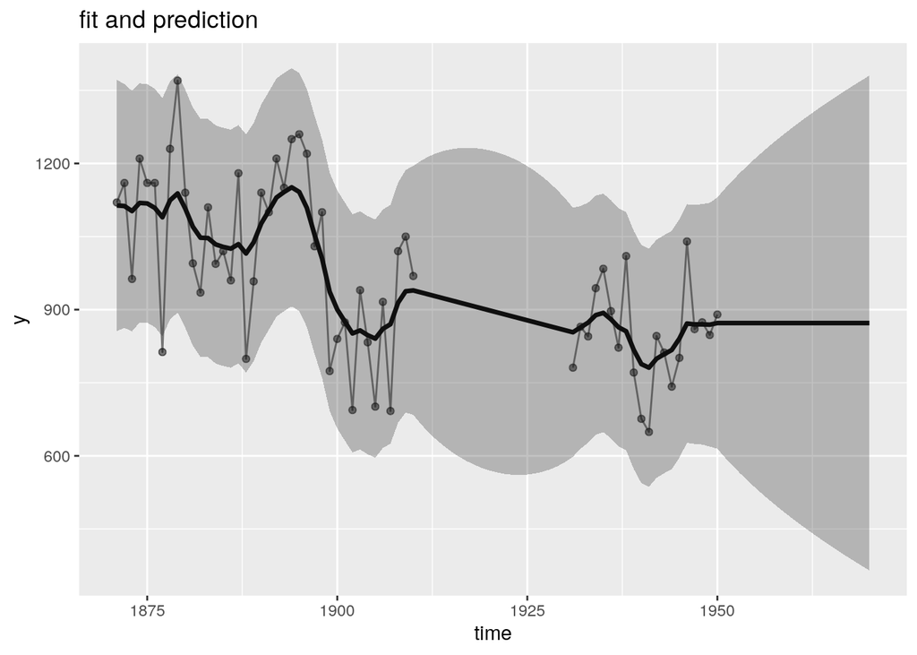

```r
forecast_pred <- predict(fit_kfas$model,
                         interval = "prediction",
                         level = 0.95,
                         n.ahead = 20)

# 図示の為予測結果を平滑化状態と結合する
estimate_all <- rbind(smooth_pred, forecast_pred)

# 図示の為データをまとめる
df_forecast <- cbind(data.frame(y = c(as.numeric(nile_train), rep(NA, 20)),
                                time = 1871:1970),
                     as.data.frame(estimate_all))

ggplot(df_forecast, aes(x = time, y = y)) +
  labs(title = "fit and prediction") +
  geom_line(alpha = 0.5) +
  geom_point(alpha = 0.5) +
  geom_line(aes(y = fit), size = 1.2) +
  geom_ribbon(aes(ymin = lwr, ymax = upr), alpha = 0.3)
```